# dataOverview

Pieter Clauw

03/06/2019

```r
library(googlesheets)
library(gdata)
library(nlme)
library(emmeans)
library(splines)
source('functions.r')
```

```r
knitr::opts_knit$set(root.dir = "/Volumes/nordborg/user/pieter.clauw/Documents/Experiments/FieldRNA/")
lemna.aug <- read.csv('/Volumes/nordborg/user/pieter.clauw/Documents/Experiments/FieldRNA/Data/Growth/ImageAnalysis/Pieter_SwedenSite_August2018.csv', sep = ';', dec = ',')
lemna.sep <- read.csv('/Volumes/nordborg/user/pieter.clauw/Documents/Experiments/FieldRNA/Data/Growth/ImageAnalysis/Nordborg_Pieter_SwedenSite_Sept2018_COMPLETE.csv', sep = ';', dec = ',')
lemna.oct <- read.csv('/Volumes/nordborg/user/pieter.clauw/Documents/Experiments/FieldRNA/Data/Growth/ImageAnalysis/Nordborg_Pieter_SwedenSite_October2018.csv', sep = ';', dec = ',')
# get meta information on each position
potInfo.gs <- gs_key("11ttBZsMiamn4zEDHUNT-L8CsK4EoAwtbSSUjTs5YEj8")
```

```
## Sheet successfully identified: "Field _Setup"
```

```r
potInfo <- as.data.frame(gs_read(potInfo.gs, ws = 'Randomisation'))
```

```
## Accessing worksheet titled 'Randomisation'.
```

```r
# get px/mm2 scael for each picture
distance.xls <- read.xls('/Volumes/nordborg/user/pieter.clauw/Documents/Experiments/FieldRNA/Data/Growth/distanceCalibration.xlsx')
emptyPots <- read.table('/Volumes/nordborg/user/pieter.clauw/Documents/Experiments/FieldRNA/Data/Growth/emptyPots.txt', head = T)
# get info on autumn temperature clusters
autumnTempClust <- read.table('/Volumes/nordborg/user/pieter.clauw/Documents/Experiments/QandD2/Results/Growth/meanAutumnTemperatureCLusters.txt', head = T)

# relative growth rates of simulated Swedish autumn
files <- list.files(path = '/Volumes/nordborg/user/pieter.clauw/Documents/Experiments/QandD2/Data/Growth/GWAS', pattern = 'relGrowthRate_avg_[0-9]*C.csv', full.names = T)
RGR.GC <- lapply(files, read.csv)
names(RGR.GC) <- unlist(lapply(files, function(path){strsplit(path, "\\/|\\_|\\.")[[1]][15]}))
```

emptyPots are pots that did not contain a plant on the respective date that the picture was taken as seen on the respective pictures. The empty pots resemble both pots left empty on purpose, plants that died, plants that were harvested.

```r
design <-data.frame('TrayNumber' = seq(1,36), 'Block' = c(rep('A', 12), rep('B', 12), rep('C', 12)), 'TrayBlockNr' = rep(seq(1,12), 3))
design$Tray <- paste(design$Block, design$TrayBlockNr, sep = '')
trays <- design$Tray

dates <- data.frame('date' = c(26082018, 17092018, 16102018, 13112018, 19042019), 'month' = factor(c('aug', 'sep', 'oct', 'nov', 'apr'), levels = c('aug', 'sep', 'oct', 'nov', 'apr'), ordered = T), 'year' = c(2018, 2018, 2018, 2018, 2019))
time0 <- strptime(26082018, format = "%d%m%Y")
dates$days <- unlist(lapply(dates$date, function(date)
  {
    date <- strptime(date, format = "%d%m%Y")
    timepoint <- round(as.numeric(difftime(date, time0, units = 'days')))
    return(timepoint)
    }))

accessions <- unique(potInfo$acn)
accessions <- accessions[accessions != 'empty_pot']

# accession visualisation
acnVis <- data.frame('name' = accessions, 'acnColour' = rainbow(n = length(accessions), s = 1, v = 1))
acnVis$accession <- unlist(lapply(acnVis$name, function(name){strsplit(name, '_')[[1]][1]}))
# include colouring for local autumn temperature clusters
autumnTempClustColours <- rainbow(6, s = 0.8, v = 1, start = 0.05, end = 0.78)
autumnTempClust$tmeanAutumnClustTemp <- factor(autumnTempClust$tmeanAutumnClustTemp, levels = c('4C', '7C', '9C', '11C', '13C', '17C'), ordered = T)
autumnTempClust$autumnTempCol <- autumnTempClustColours[autumnTempClust$tmeanAutumnClustTemp]
acnVis$tmeanAutumnTempClustTemp <- autumnTempClust$tmeanAutumnClustTemp[match(acnVis$accession, autumnTempClust$acn)]
acnVis$autumnTempCol <- autumnTempClust$autumnTempCol[match(acnVis$accession, autumnTempClust$acn)]
# marker used as reference is 14.1cm
marker <- 14.1
```

## TODO

change accesison into name where appropriate accession should change into accession ID everywhere

```r
# tray A4 in september has one correct and one incorrect image analysis
# remove the image analysis with timestamp 14.05.2019 at 13:28:44
lemna.sep <- lemna.sep[lemna.sep$Analysis.Time.Stamp != "14.05.2019 13:28:44", ]
# combine data
#lemna <- rbind(lemna.aug, lemna.sep, lemna.oct)
lemna <- rbind(lemna.aug, lemna.sep, lemna.oct)
lemna <- lemna[ ,c('ROI.Label', 'Snapshot.ID.Tag', 'ROI.Object.Sum.Area', 'Caliper.Length', 'Circumference', 'Compactness')]
lemna$pot <- unlist(lapply(lemna$ROI.Label, function(ROI)
  {
    row <- tolower(substr(ROI, 1, 1))
    col <- as.numeric(substr(ROI, 2, 3))
    pot <- paste(row, col, sep = '')
    return(pot)
  }))
# Snapshot.ID.Tag contains date and tray number
lemna$Tray <- unlist(lapply(lemna$Snapshot.ID.Tag, function(ID)
  {
    trayNr <- strsplit(ID, split = '_')[[1]][1]
    tray <- design$Tray[design$TrayNumber == trayNr]
    return(tray)
  }))
lemna$block <- unlist(lapply(lemna$Tray, function(tray){substr(tray,1,1)}))
lemna$position <- paste(lemna$Tray, lemna$pot, sep = '_')
lemna$ID <- paste(lemna$Snapshot.ID.Tag, lemna$pot, sep = '_')
lemna$date <- unlist(lapply(lemna$Snapshot.ID.Tag, function(ID){strsplit(ID, split = '_')[[1]][2]}))
lemna$month <- dates$month[match(lemna$date, dates$date)]

# multiple ROI.objects. Take only first measurement of non-zero measurements and only ROI.Object.Sum.Area
objectCount <- table(lemna$ID)
IDmulti <- names(objectCount[objectCount > 1])

for (ID in IDmulti)
{
  ID.objectCnt <- objectCount[ID]
  # check  which ones are zero and remove, decide on plants left to make NA
  #zeroNr <- nrow(lemna[lemna$ID == ID & lemna$ROI.Object.Sum.Area == 0, ])
  #if (zeroNr == ID.objectCnt){print(paste('only zero measurement for', ID, 'will be removed through emptyPot removal')); next()}
  # amount of plants that need to be removed apsart from zero area plants
  #NAIDnr <- ID.objectCnt - zeroNr
  # remove additional ROI.objects
  #if (NAIDnr > 1){lemna$ROI.Object.Sum.Area[lemna$ID == ID][2:ID.objectCnt] <- NA}
  lemna$ROI.Object.Sum.Area[lemna$ID == ID][2:ID.objectCnt] <- NA
  # remove extra measurement with zero area
  #if (zeroNr > 0){lemna$ROI.Object.Sum.Area[lemna$ID == ID & lemna$ROI.Object.Sum.Area == 0] <- NA}
}
# remove multiple ROI.objects
lemna <- lemna[!is.na(lemna$ROI.Object.Sum.Area), ]



# ROI.Label is the plant identifier

# transform pixels to cm2
# get conversion ratios per tray
distance.xls$cm[distance.xls$cm == 'marker'] <- marker
distance.xls$cm <- as.numeric(distance.xls$cm)
conversionRates <- data.frame('Date' = integer(), 'Tray' = character(), 'Columns' = character(), 'Conversion' = numeric())
for (i in 1:nrow(distance.xls))
{
  if (nchar(distance.xls$Trays[i]) < 1){next()}
  tray <- trimws(strsplit(distance.xls$Trays[i], split = ';')[[1]])
  columns <- distance.xls$columns[i]
  date <- distance.xls$date[i]
  pxls <- distance.xls$pixels[i]
  cms <- distance.xls$cm[i]
  conversion <- (cms/pxls)^2
  # for august the converison rates of the composite images (merge of two pictures of half a tray)
  if (date == '26082018' & grepl('DSC', distance.xls$original.file[i])){next()}

  convDF <- data.frame('Date' = rep(date, length(tray)), 'Tray' = tray, 'Columns' = rep(columns, length(tray)), 'Conversion' = rep(conversion, length(tray)))
  conversionRates <- rbind(conversionRates, convDF)
}

# convert pixels to mm2
lemna$AreaCm <- apply(lemna, MARGIN = 1, FUN = convertPxlToCm2, conversionRates = conversionRates)
lemna$AreaMm <- lemna$AreaCm * 10
lemna$logAreaMm <- log(lemna$AreaMm)
```

Plants were harvested every month. Remove positions that were empty in the taken pictures. (starting from October)

```r
emptyPots$Pot <- unlist(lapply(emptyPots$Pot, function(pot)
{
  row <- tolower(substr(pot, 1,1))
  col <- substr(pot, 2, nchar(pot))
  #col <- formatC(as.numeric(col), width = 2, flag = '0')
  return(paste(row, col, sep = ''))
}))

for (i in 1:nrow(emptyPots))
{
  date <- emptyPots$Date[i]
  tray <- emptyPots$Tray[i]
  pot <- emptyPots$Pot[i]
  lemna$AreaCm[lemna$Tray == tray & lemna$date == date & lemna$pot == pot] <- NA
}
lemna <- lemna[!is.na(lemna$AreaCm), ]

# check for pots with zero values
lemna$ID[lemna$AreaCm == 0]
```

```
## character(0)
```

```r
lemna$accession <- potInfo$acn[match(lemna$position, potInfo$ID)]
```

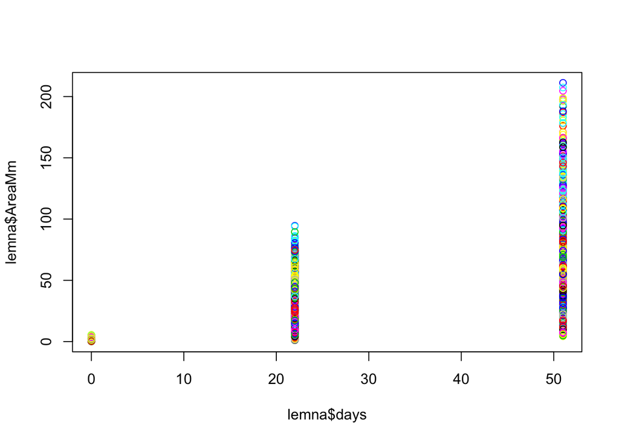

```r
# get timepoints as days
lemna$days <- dates$days[match(lemna$date, dates$date)]
plot(lemna$days, lemna$AreaMm, col = as.factor(lemna$accession))
```

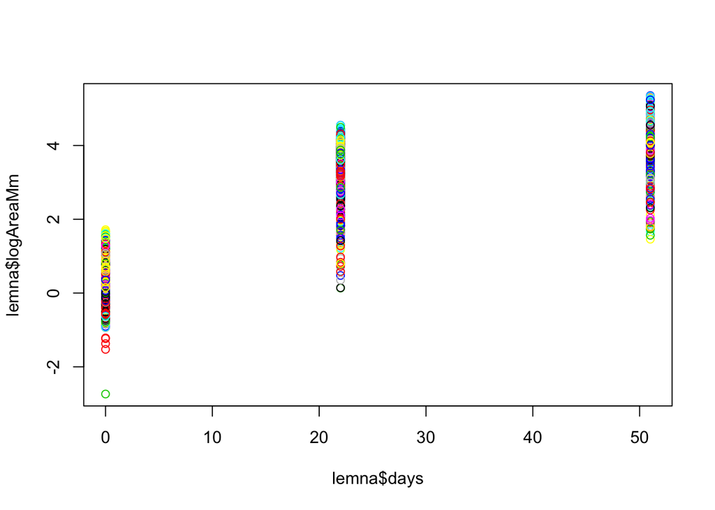

```r
plot(lemna$days, lemna$logAreaMm, col = as.factor(lemna$accession))
```

From teh plot it looks like for the logAreaMm, a polynomial model will be a better fit than a linear or quadratic model. Model with time as factor is much more heavy and does not give a better fit per se.

```r
# model with time as numeric
lmm.time <- lme(logAreaMm ~ days*accession, random = ~ 1 + days|block/position, data = lemna)
#lmm.polyTime <- lme(logAreaMm ~ (days + I(days^2) + I(days^3))*accession, random = ~ 1 + days|block/position, data = lemna)
#lmm.polyTime <- lme(logAreaMm ~ (days + I(days^2))*accession, random = ~ 1 + days|block/position, data = lemna)
# settng lmeControl to 'old' optimastion algorithm prevents lme to run out of iterations.
ctrl <- lmeControl(opt='optim')
lmm.spline <- lme(logAreaMm ~ bs(days, degree= 1, knots = 22) * accession, random = ~ 1 + days|block/position, data = lemna, control = ctrl)

# correct for heteroscedascity???
```

polynomial model requires one more timepoint than number of tested parameters. polynomial to the power 3 requires 4 timepoints. (Wait for november data). quadratic model does not converge.

```r
# create newdata for emm
nrTimepoints <- 3
predictionData <- data.frame('accession' = rep(accessions, nrTimepoints), 'days' = rep(dates$days[1:nrTimepoints], each = length(accessions)))

adjM <- emmeans(lmm.spline, ~ days * accession, cov.reduce = F, data = predictionData)
s <- summary(adjM)
emm <- data.frame('days' = s$days, 'accession' = s$accession, 'logAreaMm' = s$emmean, 'SE' = s$SE, 'df' = s$df)
```

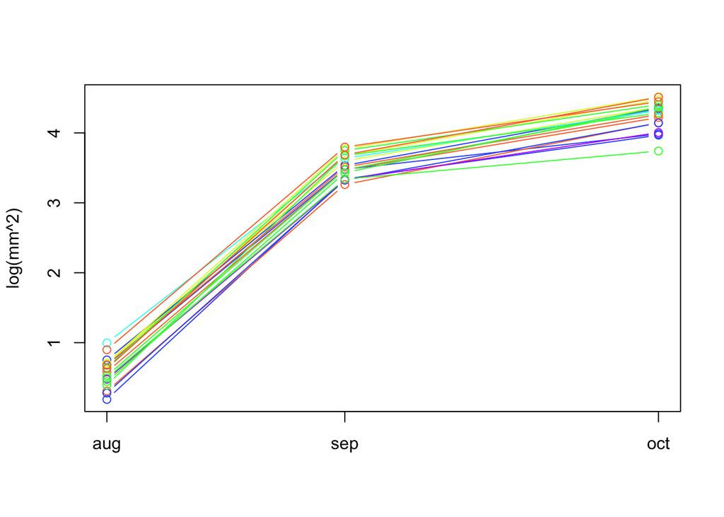

```r
minLogArea <- min(emm$logAreaMm)
maxLogArea <- max(emm$logAreaMm)
minDays <- min(emm$days)
maxDays <- max(emm$days)
plot(NA,NA, xlim = c(minDays, maxDays), ylim = c(minLogArea, maxLogArea), xaxt = 'n', xlab = '', ylab = "log(mm^2)")
for (acn in accessions)
{
  emm.a <- emm[emm$accession == acn, ]
  lines(emm.a$days, emm.a$logAreaMm, type = 'b', col = acnVis$autumnTempCol[acnVis$accession == strsplit(acn, '_')[[1]][1]])
}
# xaxis with months
axis(side = 1, at = unique(emm$days), labels = dates$month[1:nrTimepoints])
```

```r
#legend('topleft', legend = acnVis$accession)
```

```r
RGR <- data.frame('accession' = character(), 'days' = numeric(), 'rgr' = numeric())

days <- unique(emm$days)
for (i in 2:length(days))
{
  for (acn in accessions)
  {
    day1 <- days[i-1]
    day2 <- days[i]
    emm.time.acn <- emm[emm$days %in% c(day1, day2) & emm$accession == acn, ]
    mod <- lm(logAreaMm ~ days, data = emm.time.acn)
    rgr <- mod$coefficients[2]
    period <- paste(dates$month[dates$days == day1], dates$month[dates$days == day2], sep = '_')

    RGR.time.acn <- data.frame('accession' = acn, 'days' = mean(c(day1, day2)), 'period' = period, 'rgr' = rgr)
    RGR <- rbind(RGR, RGR.time.acn)
  }
}
```

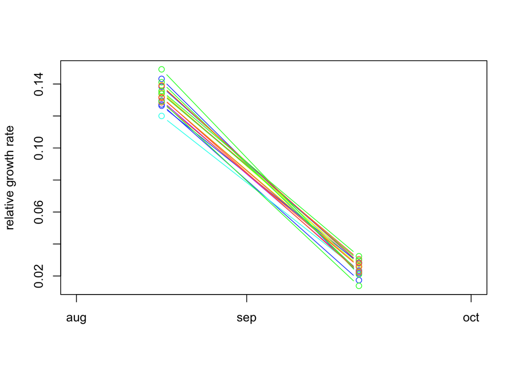

```r
minRGR <- min(RGR$rgr)
maxRGR <- max(RGR$rgr)
plot(NA,NA, xlim = c(minDays, maxDays), ylim = c(minRGR, maxRGR), xaxt = 'n', xlab = '', ylab = "relative growth rate")
for (acn in accessions)
{
  RGR.a <- RGR[RGR$accession == acn, ]
  lines(RGR.a$days, RGR.a$rgr, type = 'b', col = acnVis$autumnTempCol[acnVis$accession == strsplit(acn, '_')[[1]][1]])
}
# xaxis with months
axis(side = 1, at = unique(emm$days), labels = dates$month[1:nrTimepoints])
```

```r
#legend('topleft', legend = acnVis$accession)
```

## Correlate relative grotw rates with mean local autumn temperature

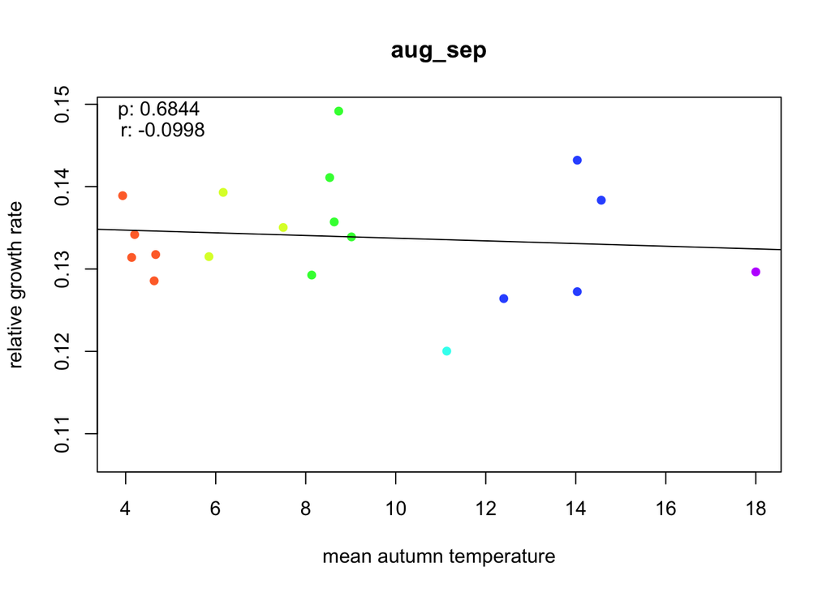

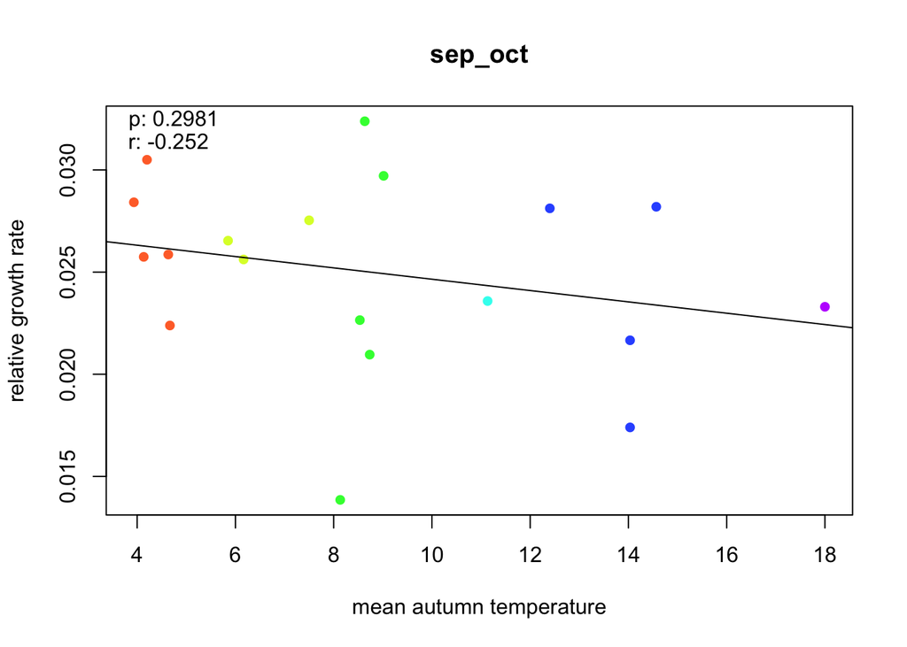

```r
RGR$acn <- unlist(lapply(RGR$accession, function(x){strsplit(x, '_')[[1]][1]}))
RGR$autumnTemp <- autumnTempClust$meanAutumn[match(RGR$acn, autumnTempClust$acn)]/10
RGR$autumnTempCol <- acnVis$autumnTempCol[match(RGR$acn, acnVis$accession)]
minAutumnTemp <- min(RGR$autumnTemp, na.rm = T)
maxAutumnTemp <- max(RGR$autumnTemp, na.rm = T)

#plot(NA,NA, xlim = c(minAutumnTemp, maxAutumnTemp), ylim = c(minRGR, maxRGR))
for(period in unique(RGR$period))
{
  RGR.p <- RGR[RGR$period == period, ]
  plot(RGR.p$autumnTemp, RGR.p$rgr, col = RGR.p$autumnTempCol, pch = 16, xlab = 'mean autumn temperature', ylab = 'relative growth rate', main = period)
  abline(lm(RGR.p$rgr ~ RGR.p$autumnTemp))
  ct <- cor.test(RGR.p$autumnTemp, RGR.p$rgr)
  text(x = par('usr')[1], y = par('usr')[4], paste('p: ', format.pval(ct$p.value, digits = 3, eps = 0.0001, nsmall = 4), sep = '' ), adj = c(-0.25 ,1.25))
  text(x = par('usr')[1], y = par('usr')[4], paste('r: ', round(ct$estimate, 4), sep = '' ), adj = c(-0.275 ,2.75))
}
```

## correlate growth chamber and field growth

Correlate per temperature in growth chamber.

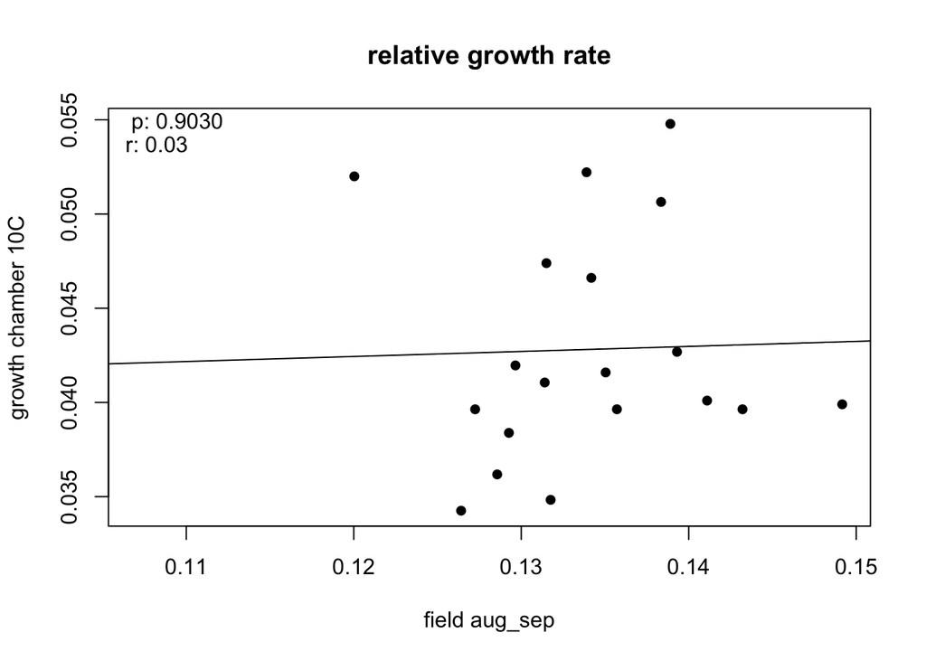

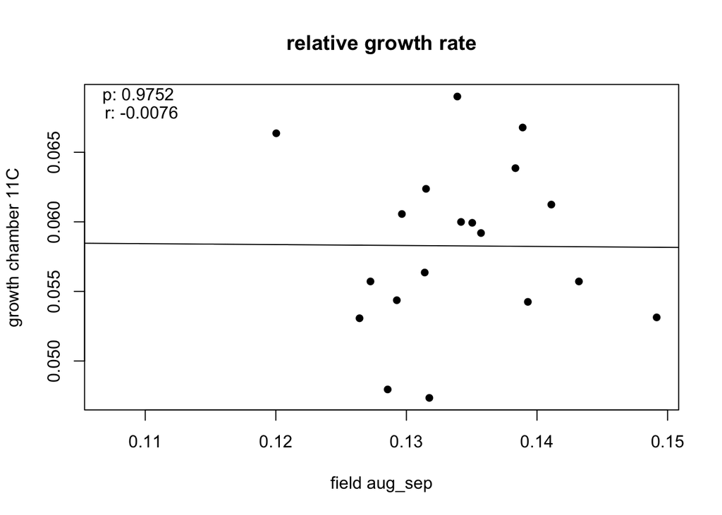

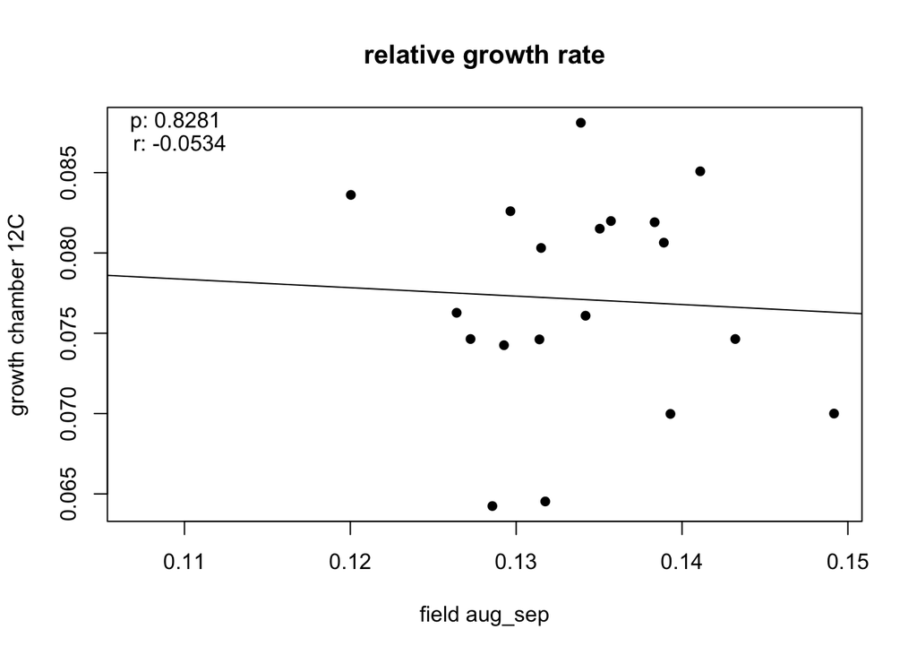

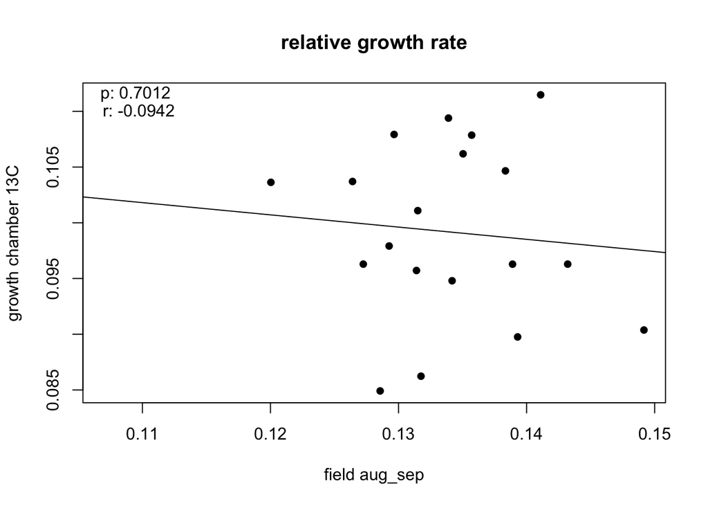

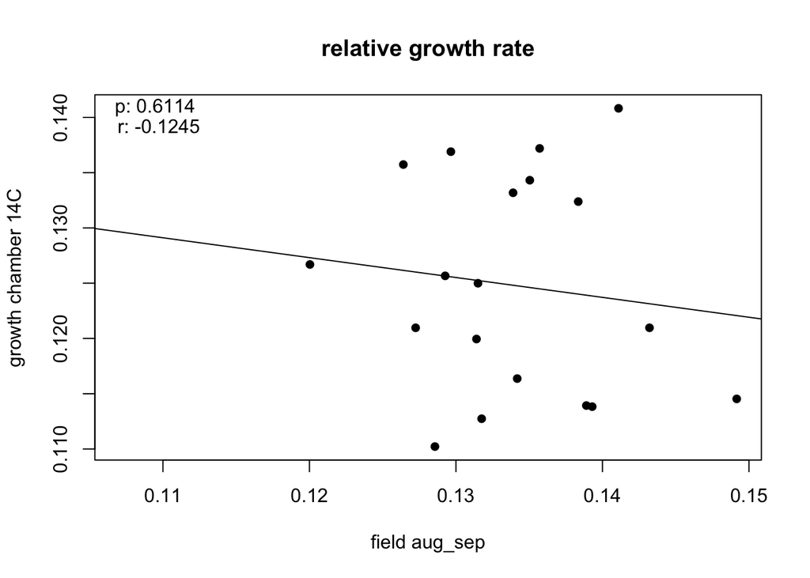

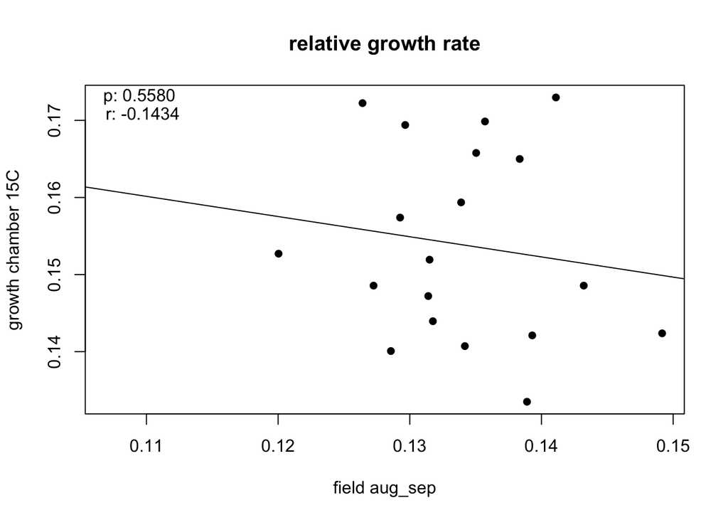

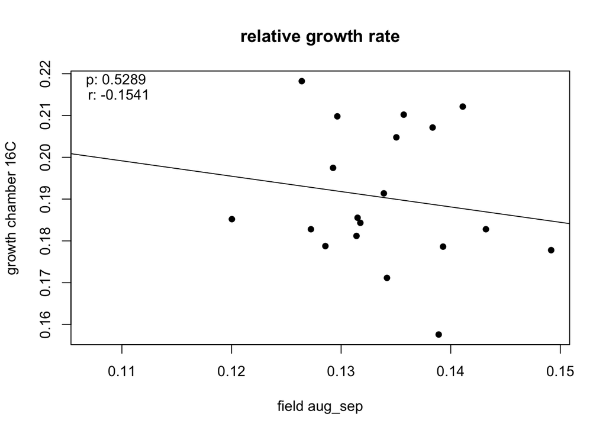

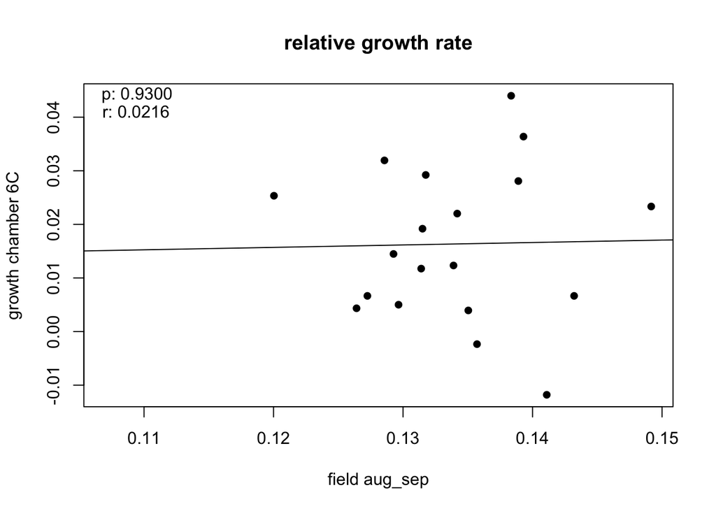

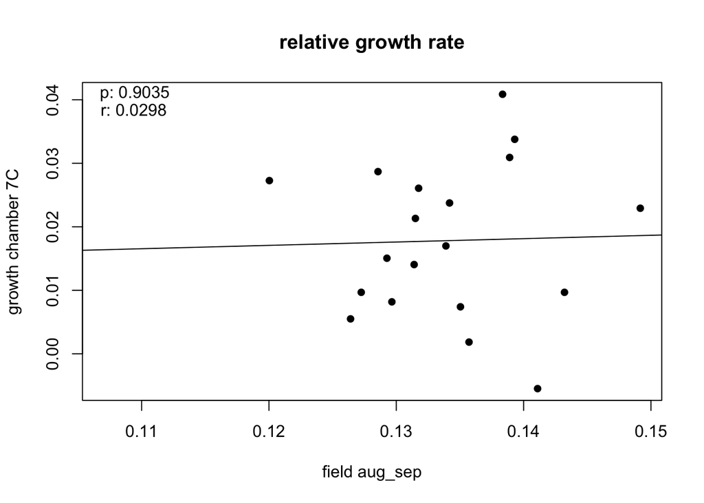

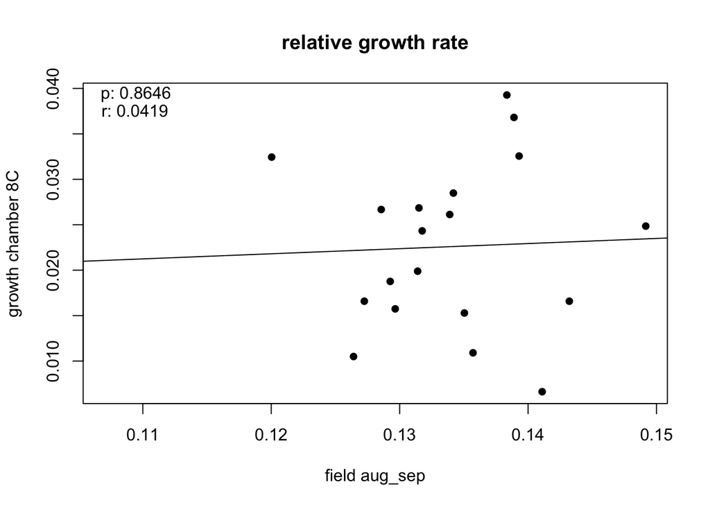

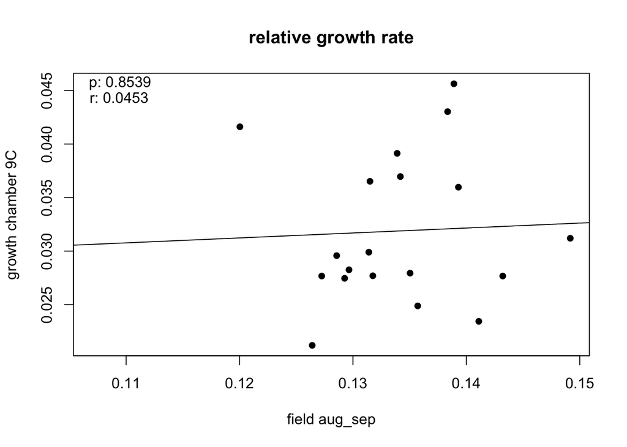

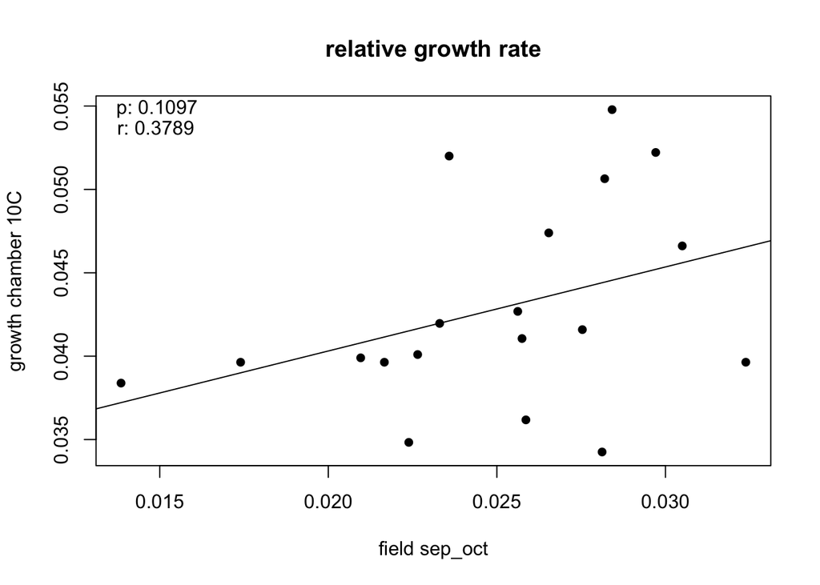

[10 more figures not shown]

```r
# merge results from RGR in growth chamber formn different temperatures to RGR in field
for(temp in names(RGR.GC))
{
  RGR.GC.C <- RGR.GC[[temp]]
  #RGR <- cbind(RGR, RGR.GC.C$relgr[match(RGR$acn, RGR.GC.C$acn)])
  RGR[, paste('rgr', temp, sep = '_')] <- RGR.GC.C$relgr[match(RGR$acn, RGR.GC.C$acn)]
}

for (period in unique(RGR$period))
{
  for (temp in names(RGR.GC))
  {
    RGR.p <- RGR[RGR$period == period, ]
    plot(RGR.p$rgr, RGR.p[,paste('rgr', temp, sep = '_')], xlab = paste('field', period), ylab = paste('growth chamber', temp), main = 'relative growth rate', pch = 16)
    abline(lm(RGR.p[,paste('rgr', temp, sep = '_')] ~ RGR.p$rgr))
    ct <- cor.test(RGR.p$rgr, RGR.p[,paste('rgr', temp, sep = '_')])
    text(x = par('usr')[1], y = par('usr')[4], paste('p: ', format.pval(ct$p.value, digits = 3, eps = 0.0001, nsmall = 4), sep = '' ), adj = c(-0.25 ,1.25))
    text(x = par('usr')[1], y = par('usr')[4], paste('r: ', round(ct$estimate, 4), sep = '' ), adj = c(-0.275 ,2.75))
  }

}
```